This dataset is an exercice, for each markdown in french i will make a brief translation in english. Sorry for my english, trying my best here.  
for any questions don't hesitate ! I am a beginner learning alone so any tips are welcome.

# Importation des libraries

```python
import pandas as pd
import numpy as np
import matplotlib.pyplot as plt
import seaborn as sns
from skimpy import skim, generate_test_data
```

# Ouverture du fichier et premier regard

```python
df = pd.read_csv("Desktop/ALL/Learning Data/Jeux de données/Mall_Customers.csv")
df.head()
```

|  | CustomerID | Gender | Age | Annual Income (k$) | Spending Score (1-100) |
| --- | --- | --- | --- | --- | --- |
| 0 | 1 | Male | 19 | 15 | 39 |
| 1 | 2 | Male | 21 | 15 | 81 |
| 2 | 3 | Female | 20 | 16 | 6 |
| 3 | 4 | Female | 23 | 16 | 77 |
| 4 | 5 | Female | 31 | 17 | 40 |

```python
skim(df) #generate a decribe focntion for the dataframe
```

```
╭──────────────────────────────────────────────── skimpy summary ─────────────────────────────────────────────────╮
│          Data Summary                Data Types                                                                 │
│ ┏━━━━━━━━━━━━━━━━━━━┳━━━━━━━━┓ ┏━━━━━━━━━━━━━┳━━━━━━━┓                                                          │
│ ┃ dataframe         ┃ Values ┃ ┃ Column Type ┃ Count ┃                                                          │
│ ┡━━━━━━━━━━━━━━━━━━━╇━━━━━━━━┩ ┡━━━━━━━━━━━━━╇━━━━━━━┩                                                          │
│ │ Number of rows    │ 200    │ │ int32       │ 4     │                                                          │
│ │ Number of columns │ 5      │ │ string      │ 1     │                                                          │
│ └───────────────────┴────────┘ └─────────────┴───────┘                                                          │
│                                                     number                                                      │
│ ┏━━━━━━━━━━━━━━━━━━━━━━━━━━━━━━━━┳━━━━━━┳━━━━━━━━━┳━━━━━━━━━┳━━━━━━┳━━━━━━┳━━━━━━━┳━━━━━━━┳━━━━━━━━┳━━━━━━━━━┓  │
│ ┃ column_name                    ┃ NA   ┃ NA %    ┃ mean    ┃ sd   ┃ p0   ┃ p25   ┃ p75   ┃ p100   ┃ hist    ┃  │
│ ┡━━━━━━━━━━━━━━━━━━━━━━━━━━━━━━━━╇━━━━━━╇━━━━━━━━━╇━━━━━━━━━╇━━━━━━╇━━━━━━╇━━━━━━━╇━━━━━━━╇━━━━━━━━╇━━━━━━━━━┩  │
│ │ CustomerID                     │    0 │       0 │     100 │   58 │    1 │    51 │   150 │    200 │ ██████  │  │
│ │ Age                            │    0 │       0 │      39 │   14 │   18 │    29 │    49 │     70 │ ▆█▄▅▃▂  │  │
│ │ Annual Income (k$)             │    0 │       0 │      61 │   26 │   15 │    42 │    78 │    140 │ ▅▇█▅▂▁  │  │
│ │ Spending Score (1-100)         │    0 │       0 │      50 │   26 │    1 │    35 │    73 │     99 │ ▅▃█▇▅▄  │  │
│ └────────────────────────────────┴──────┴─────────┴─────────┴──────┴──────┴───────┴───────┴────────┴─────────┘  │
│                                                     string                                                      │
│ ┏━━━━━━━━━━━━━━━━━━━━━━━━━━━┳━━━━━━━━━┳━━━━━━━━━━━━┳━━━━━━━━━━━━━━━━━━━━━━━━━━━━━━┳━━━━━━━━━━━━━━━━━━━━━━━━━━┓  │
│ ┃ column_name               ┃ NA      ┃ NA %       ┃ words per row                ┃ total words              ┃  │
│ ┡━━━━━━━━━━━━━━━━━━━━━━━━━━━╇━━━━━━━━━╇━━━━━━━━━━━━╇━━━━━━━━━━━━━━━━━━━━━━━━━━━━━━╇━━━━━━━━━━━━━━━━━━━━━━━━━━┩  │
│ │ Gender                    │       0 │          0 │                            1 │                      200 │  │
│ └───────────────────────────┴─────────┴────────────┴──────────────────────────────┴──────────────────────────┘  │
╰────────────────────────────────────────────────────── End ──────────────────────────────────────────────────────╯
```

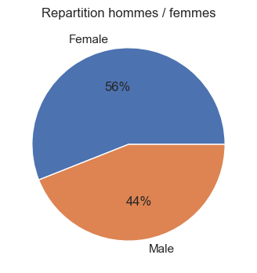

```python
Gender_count = df.groupby("Gender").size()
plt.figure(figsize=[4,4])
plt.pie(Gender_count, labels=Gender_count.index, autopct='%.0f%%')
plt.title("Repartition hommes / femmes")
plt.show()
```

## Premieres informations

De plus nous pouvons voir que 112 clients sont des femmes(56%) et 88 sont des hommes(44%)

*Here we have a dataset with 200 rows and 5 columns with no missing values. We can see that 56% of customers are women (112 in this dataset) and 44% are men(88 in total).*

### Revenu moyen et score moyen de dépense en fonction du genre

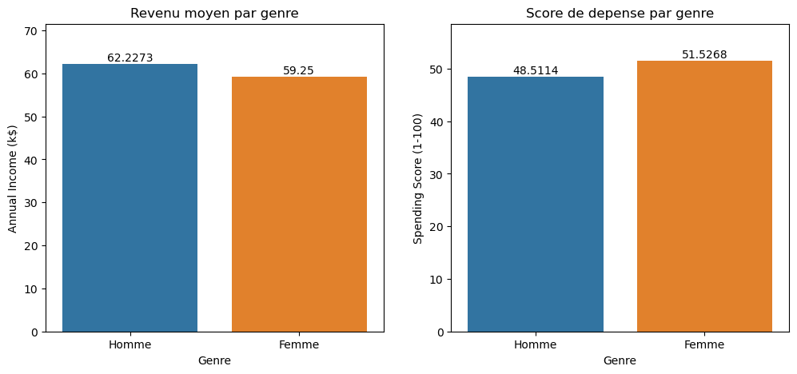

```python
plt.figure(figsize=[12,5])
plt.subplot(121)
ax = sns.barplot(data= df, x="Gender", y="Annual Income (k$)",errwidth=0)
ax.bar_label(ax.containers[0])
plt.title("Revenu moyen par genre")
plt.xlabel("Genre")
plt.xticks(np.arange(2),["Homme","Femme"])
plt.subplot(122)
ay = sns.barplot(data= df, x="Gender", y="Spending Score (1-100)",errwidth=0)
ay.bar_label(ay.containers[0])
plt.title("Score de depense par genre")
plt.xlabel("Genre")
plt.xticks(np.arange(2),["Homme","Femme"])
plt.show()
```

Ici nous pouvons remarquer qu'en moyenne les hommes ont un revenu un peu plus élevé que les femmes (environ 3k par an) mais que les femmes ont un score de dépense plus élevé de 3 points en moyenne.

*We can see that men in this mall have a better Annual income than women, however women have a higher spending score .*

## Impact de l'âge sur les différentes variables

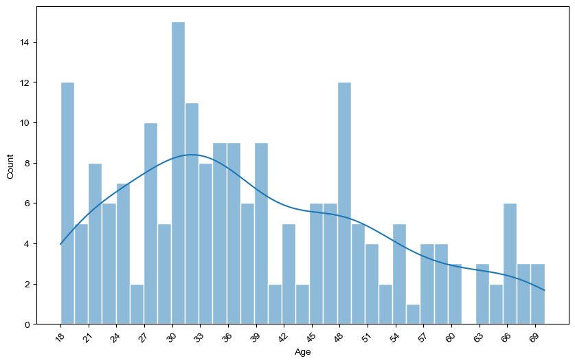

```python
plt.figure(figsize=[10,6])
plt.subplot(111)
custom_params = {"axes.spines.right": False, "axes.spines.top": False}
sns.set_theme(style="ticks", rc=custom_params)
ax = sns.histplot(data = df, x="Age", bins=35, kde=True)
plt.xticks(np.arange(18, 70, step=3), rotation =45)
plt.show()
```

```python
Age_homme = df.loc[df["Gender"] == "Male"]
Age_femme = df.loc[df["Gender"] == "Female"]
print(f"L'âge moyen des hommes dans ce magasin est de {round(Age_homme['Age'].mean(),2)} ans, celuis des femmes et de {round(Age_femme['Age'].mean(),2)} ans")
```

```
L'âge moyen des hommes dans ce magasin est de 39.81 ans, celuis des femmes et de 38.1 ans
```

Nous pouvons remarquer plusieurs choses. Tout d'abord l'age moyen Hommes/femmes est très similaire à un an près soit 39 ans, deuxièmement la majorité des client semblent (75%) ont moint de 49 ans. Analysons maintenant l'impact de l'âge sur les revenus ainsi que que sur le core de dépense.

*Men and women have a similar middle age which is 39 years old. 75% of the mall's custommers are less than 49 years old.*

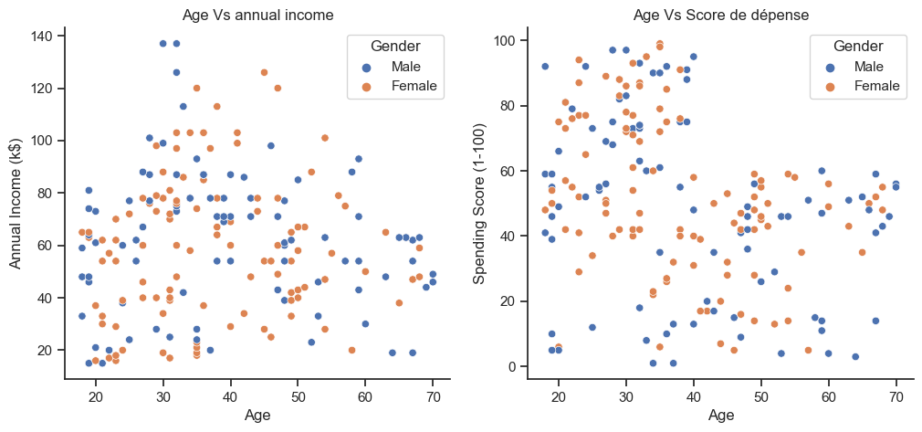

```python
plt.figure(figsize=[12,5])
plt.subplot(121)
ax= sns.scatterplot(df, x= "Age", y="Annual Income (k$)", hue="Gender")
plt.title("Age Vs annual income")
plt.subplot(122)
ay = sns.scatterplot(df, x="Age", y="Spending Score (1-100)", hue= "Gender")
plt.title("Age Vs Score de dépense")
plt.show()
```

Sur ces deux graphiques nous avons très peu de corrélation visible, cependant nous pouvons tout de même noter qu'il semblerait que les personnes ayant les plus gros revenus annuel se situent pour la plupart entre 30 et 50 ans et que les plus dépensier on entre 20 et 40 ans.  
Allons plus en profondeur en utilisant un autre type de graphique qui nous donnera peut être plus de précision.

*In this two charts we have few correlation but still we can note that it seems that people with higher income are between 30 and 50 years old and those with higher spending score are between 20 and 40 years old.*

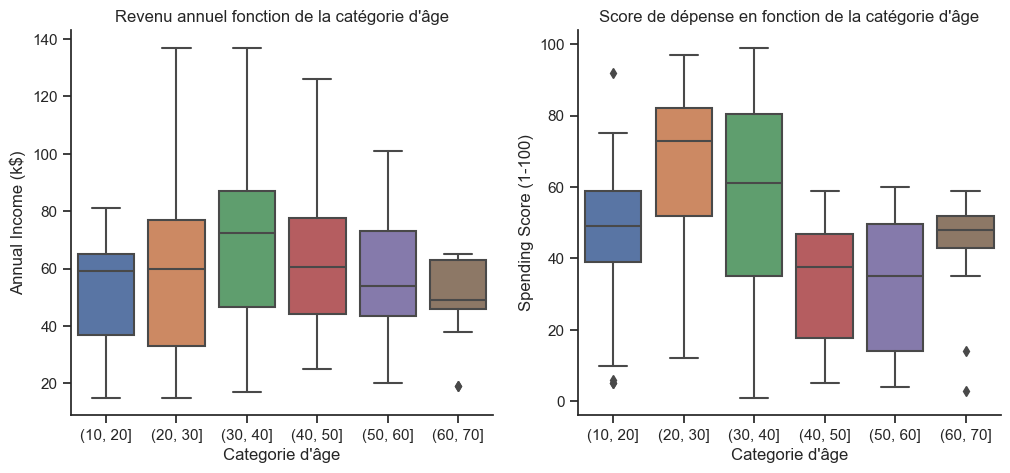

```python
df['age_bins'] = pd.cut(x=df['Age'], bins=[10,20,30,40,50,60,70])
palette = sns.color_palette(palette='Accent')
sns.set_palette(palette)
custom_params = {"axes.spines.right": False, "axes.spines.top": False}
sns.set_theme(style="ticks", rc=custom_params)
plt.figure(figsize=[12,5])
plt.subplot(121)
sns.boxplot(df, x="age_bins", y="Annual Income (k$)")
plt.title("Revenu annuel fonction de la catégorie d'âge")
plt.xlabel("Categorie d'âge")
plt.subplot(122)
sns.boxplot(df, x="age_bins", y= "Spending Score (1-100)")
plt.title("Score de dépense en fonction de la catégorie d'âge")
plt.xlabel("Categorie d'âge")
plt.show()
```

Ces deux graphiques nous permettent d'être un peu plus précis. Ici nous pouvons affirmer que les personnes entre 30 et 40 ans sont celles qui possèdent un meilleur revenu annuel et que les perseonnes de plus de 60 ans sont celles qui gagnent le moins.  
De plus le deuxième graphique nous montre que le les personnes entre 20 et 30 ans sont celles qui dépensent le plus.

*People between 30 and 40 years old are the one earning more money by year contrary to people who are 60 years old or more which are the one having the lowest annual income.*

## Analyse du score de dépense en fonction du revenu annuel

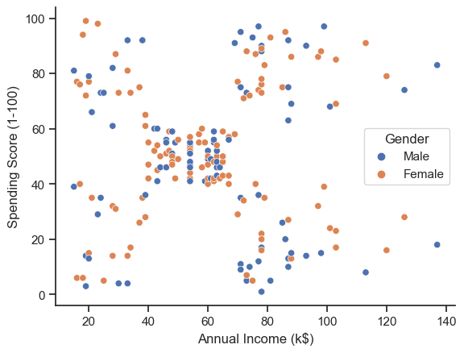

```python
plt.figure()
plt.subplot(111)
sns.scatterplot(df,x="Annual Income (k$)", y= "Spending Score (1-100)", hue="Gender")
```

Encore une fois ce graphique n'affiche pas de tendances très claire. Essayons de regrouper par catégories de revenus afin d'affiner notre analyse.

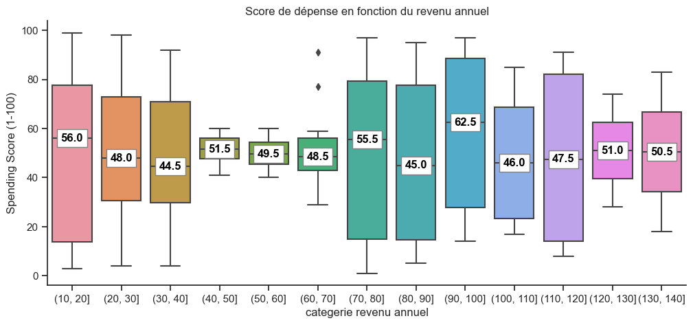

```python
df["cat_income"] = pd.cut(x=df['Annual Income (k$)'], bins=[10,20,30,40,50,60,70,80,90,100,110,120,130,140])
count_cat_inc = df.groupby(df["cat_income"].value_counts())
palette = sns.color_palette(palette='Accent')
sns.set_palette(palette)
custom_params = {"axes.spines.right": False, "axes.spines.top": False}
sns.set_theme(style="ticks", rc=custom_params)
plt.figure(figsize=[12,5])
plt.subplot(111)
ax = sns.boxplot(df, x="cat_income", y="Spending Score (1-100)")

lines = ax.get_lines()
categories = ax.get_xticks()

for cat in categories:
    y = round(lines[4+cat*6].get_ydata()[0],1)
    ax.text(
        cat,
        y,
        f'{y}',
        ha='center',
        va='center',
        fontweight='semibold',
        size=12,
        color='Black',
        bbox=dict(facecolor='White', edgecolor='#828282')
    )
plt.title("Score de dépense en fonction du revenu annuel")
plt.xlabel("categerie revenu annuel")
plt.show()
```

Ici nous observons un fait très interessant. Les clients ayant un revenu entre 40K et 70K par an on un score de dépense très proches avec peu de variation, en revanche les personnes avec un revenu de 70K à 120K ont des variations très élevés. C'est a dire que certains client dans cette tranche de revenu ont un score de dépense faible(<30) alors que d'autres dans cette même catégorie ont un score de dépense très fort(>80). Essayons de trouver une explication à cela.

*We have an interesting fact here. Custommers with an annual income between 40K and 70K have few variations in their spending score, on the other hand custommers with an annual income more important have high variations in their spending score. This means that people in this range can have a high spending score(>80) or a very low one*

```python
df2 = df.loc[(df['Annual Income (k$)'] <=40) & (df['Annual Income (k$)'] >=0)]
print(df2["Age"].mean())
df3 = df.loc[(df['Annual Income (k$)'] <=70) & (df['Annual Income (k$)'] >40)]
print(df3["Age"].mean())
df4 = df.loc[(df['Annual Income (k$)'] <=140) & (df['Annual Income (k$)'] >70)]
print(df4["Age"].mean())
```

```
35.28
43.276315789473685
36.71621621621622
```

Nous avons un élément de réponse ici. Les personnes gagnant entre 40K et 70K par an ont une moyenne d'âge plus élevé (43 ans) que ceux qui gagnent moins que eux ou plus qu'eux(36 ans environ). Plusieurs interpretations sont possibles:

- ces personnes dépensent leur argent de façon prévisible et standardisé comme pour les courses et tout ce dont leur foyer a besoin. Une sorte de routine de dépense possiblement lié à une situation familiale plus stable et des prêts liés a leur situation( maison, voiture ou autre)
- Les personnes plus jeunes ayant une variation plus importante de leur dépense ont peut être plus tendance à varier leurs habitudes de consommation d'une période à l'autre et donc sont moins regardant sur leur dépense.

Custommers earning between 40K and 70K are older (43 years old on average) than people earning less (36 years old on average): -This people use their money in a standardised way like furnitures and everything their home needs. There is a routine in how they spend their money. This is probably related to a stable situation due to their family and their rent (home, car or anything else). -Younger custommers which have a greater variation of their spending score tend to change their habits of consumptions which can be high or low depending of their lifestyle and maybe their balance account.

# Conclusion

Ce jeu de données simple est un bon exercice pour s'exercer sur les bases de l'analyse de données.  
En revanche il présente plusieurs défauts:

- Le nombre de variables est limité il manque par exemple la situation familiale (enfant, mariage ect ...), ou encore le nombre d'achat par client.
- L'échantillon de 200 individus est trop petit
- Peu de corrélation entre les variables

Nous pouvons donc tiré peu de conclusions réelements fiables pour donner des indications aux dirigeants du magasin avec le peu de données dont nous disposons.

This dataset is a good exercice to practise some basics EDA. However the variables are limited, there are others parameters it would have been great to take on consideration like family situation, number of children and so on. Moreover there is a lack of data, the sample is small and the correlations between the variables are very low. So there is few conclusions we can settle here but we do with what we have :D

### MERCI / THANK YOU

Merci de commenter si vous avez des remarques ou des conseils a me donner afin d'améliorer mon travail.  
Leave a comment if you liked my work and any comment would be great in order to improve myself.